# 2.33

# (i)

For $n=2$, we have $$e^{\mathbf{A}t} = p_1(t)\mathbf{M}_0 + p_2(t) \mathbf{M}_1$$ where $$ \begin{align*} \mathbf{M}_0 &= \mathbf{I}, \\ \\ \mathbf{M}_1 &= \prod_{k=1}^1 (\mathbf{A}-\lambda_k \mathbf{I}) = (\mathbf{A}-\lambda_1\mathbf{I}),\\ \\ p_1' &= \lambda_1 p_1, \quad \quad \quad p_1(0)=1, \\ p_2' &= p_1 + \lambda_2 p_2, \quad p_2(0) = 0. \end{align*} $$

The eigenvalues are given by (using the trace-determinant shortcut from earlier)

$$ 0 = \lambda^2 - (1 + -1) \lambda + [(1)(-1) - 2(-5)] = \lambda^2 + 9,$$

and so $\lambda = \pm 3i.$ We can label $\lambda_1 = 3i, \lambda_2 = -3i.$

We have

$$\mathbf{M}_1 = \mathbf{A} - 3i \mathbf{I} = \left[ \begin{array}{cc} 1 - 3i & 2 \\ -5 & -1-3i \end{array} \right].$$

Next,

$$ p_1' = 3i p_1, \quad p_1(0) = 1 \implies p_1(t) = e^{3i t}.$$

Then,

$$ p_2' = p_1 -3i p_2 \implies p_2' + 3i p_2 = e^{3i t}.$$

We can use the integrating factor $e^{\int 3i \, dt} = e^{3it},$ leading to

$$p_2' e^{3it} + 3i e^{3it} p_2 = e^{6it} \implies \frac{d}{dt}\left( p_2 e^{3i t} \right) = e^{6it} \implies p_2 e^{3it} = \frac{1}{6i} e^{6i t} + C.$$

The initial condition $p_2(0) = 0$ means $C = -\dfrac{1}{6i}$ and so

$$p_2 e^{3i t} = \frac{1}{6i}e^{6it} - \frac{1}{6i} \implies p_2 = \frac{1}{6i}e^{3it} - \frac{1}{6i}e^{-3it} = \frac 1 3 \sin(3t),$$

using $\sin(kt) = \dfrac{e^{ikt}-e^{-ikt}}{2i}.$

Putting it together,

$$ \begin{align*} e^{\mathbf{A}t} &= p_1(t) \mathbf{M}_0 + p_2(t) \mathbf{M}_1 \\ \\ &= e^{3i t} \left[ \begin{array}{cc} 1 & 0 \\ 0 & 1 \end{array} \right] + \frac 1 3 \sin(3t) \left[ \begin{array}{cc} 1-3i & 2 \\ -5 & -1-3i \end{array} \right] \\ \\ &= [\cos(3t) + i \sin(3t)] \left[ \begin{array}{cc} 1 & 0 \\ 0 & 1 \end{array} \right] + \frac 1 3 \sin(3t) \left[ \begin{array}{cc} 1-3i & 2 \\ -5 & -1-3i \end{array} \right] \\ \\ &= \left[ \begin{array}{cc} \cos(3t) + \frac 1 3 \sin(3t) & \frac{2}{3} \sin(3t) \\ -\frac{5}{3} \sin(3t) & \cos(3t) - \frac 1 3 \sin(3t) \end{array} \right]. \end{align*} $$

We can check our answer with SymPy:

```python
#@title 2.33(i) check
from sympy import Symbol, Matrix, latex, simplify, exp
from IPython.display import display, Math


t = Symbol('t', real=True)

#Here is where you enter the matrix as a list of the rows.
A = Matrix([[1,2],[-5,-1]])
expA = simplify(exp(A*t))



display(Math(r'\mathbf{A}='+latex(A)))
print()
print()
display(Math(r'e^{\mathbf{A}t}='+latex(expA)))
```

$\displaystyle \mathbf{A}=\left[\begin{matrix}1 & 2\\-5 & -1\end{matrix}\right]$

$\displaystyle e^{\mathbf{A}t}=\left[\begin{matrix}\frac{\sin{\left(3 t \right)}}{3} + \cos{\left(3 t \right)} & \frac{2 \sin{\left(3 t \right)}}{3}\\- \frac{5 \sin{\left(3 t \right)}}{3} & - \frac{\sin{\left(3 t \right)}}{3} + \cos{\left(3 t \right)}\end{matrix}\right]$

# (ii)

For $n=2$, we have $$e^{\mathbf{A}t} = p_1(t)\mathbf{M}_0 + p_2(t) \mathbf{M}_1$$ where $$ \begin{align*} \mathbf{M}_0 &= \mathbf{I}, \\ \\ \mathbf{M}_1 &= \prod_{k=1}^1 (\mathbf{A}-\lambda_k \mathbf{I}) = (\mathbf{A}-\lambda_1\mathbf{I}),\\ \\ p_1' &= \lambda_1 p_1, \quad \quad \quad p_1(0)=1, \\ p_2' &= p_1 + \lambda_2 p_2, \quad p_2(0) = 0. \end{align*} $$

The eigenvalues are given by (using the trace-determinant shortcut from earlier)

$$ 0 = \lambda^2 - (2+2) \lambda + [2(2) - 3(-3)] = \lambda^2 -4\lambda +13 = (\lambda-2)^2 + 9,$$

and so $\lambda = 2 \pm 3i.$ We can label $\lambda_1 =2+ 3i, \lambda_2 = 2-3i.$

We have

$$\mathbf{M}_1 = \mathbf{A} - (2+3i) \mathbf{I} = \left[ \begin{array}{cc} - 3i & 3 \\ -3 & -3i \end{array} \right].$$

Next,

$$ p_1' = (2+3i) p_1, \quad p_1(0) = 1 \implies p_1(t) = e^{(2+3i) t}.$$

Then,

$$ p_2' = p_1 +(2-3i) p_2 \implies p_2' + (-2+3i) p_2 = e^{(2+3i) t}.$$

We can use the integrating factor $e^{\int (-2+3i) \, dt} = e^{(-2+3i)t},$ leading to

$$p_2' e^{(-2+3i)t} + (-2+3i) e^{(-2+3i)t} p_2 = e^{6it} \implies \frac{d}{dt}\left( p_2 e^{(-2+3i) t} \right) = e^{6it} \implies p_2 e^{(-2+3i)t} = \frac{1}{6i} e^{6i t} + C.$$

The initial condition $p_2(0) = 0$ means $C = -\dfrac{1}{6i}$ and so

$$p_2 e^{(-2+3i) t} = \frac{1}{6i}e^{6it} - \frac{1}{6i} \implies p_2 = \frac{1}{6i}e^{(2+3i)t} - \frac{1}{6i}e^{(2-3i)t} = \frac 1 3 e^{2t} \sin(3t),$$

using $\sin(kt) = \dfrac{e^{ikt}-e^{-ikt}}{2i}.$

Putting it together,

$$ \begin{align*} e^{\mathbf{A}t} &= p_1(t) \mathbf{M}_0 + p_2(t) \mathbf{M}_1 \\ \\ &= e^{(2+3i) t} \left[ \begin{array}{cc} 1 & 0 \\ 0 & 1 \end{array} \right] + \frac 1 3e^{2t} \sin(3t) \left[ \begin{array}{cc} -3i & 3 \\ -3 & -3i \end{array} \right] \\ \\ &= e^{2t}[\cos(3t) + i \sin(3t)] \left[ \begin{array}{cc} 1 & 0 \\ 0 & 1 \end{array} \right] + \frac 1 3 e^{2t}\sin(3t) \left[ \begin{array}{cc} -3i & 3 \\ -3 & -3i \end{array} \right] \\ \\ &= \left[ \begin{array}{cc} e^{2t}\cos(3t) &e^{2t} \sin(3t) \\ -e^{2t} \sin(3t) & e^{2t}\cos(3t) \end{array} \right]. \end{align*} $$

We can check our answer with SymPy:

```python
#@title 2.33(ii) check
from sympy import Symbol, Matrix, latex, simplify, exp
from IPython.display import display, Math


t = Symbol('t', real=True)

#Here is where you enter the matrix as a list of the rows.
A = Matrix([[2,3],[-3,2]])
expA = simplify(exp(A*t))



display(Math(r'\mathbf{A}='+latex(A)))
print()
print()
display(Math(r'e^{\mathbf{A}t}='+latex(expA)))
```

$\displaystyle \mathbf{A}=\left[\begin{matrix}2 & 3\\-3 & 2\end{matrix}\right]$

$\displaystyle e^{\mathbf{A}t}=\left[\begin{matrix}e^{2 t} \cos{\left(3 t \right)} & e^{2 t} \sin{\left(3 t \right)}\\- e^{2 t} \sin{\left(3 t \right)} & e^{2 t} \cos{\left(3 t \right)}\end{matrix}\right]$

# (iii)

For $n=2$, we have $$e^{\mathbf{A}t} = p_1(t)\mathbf{M}_0 + p_2(t) \mathbf{M}_1$$ where $$ \begin{align*} \mathbf{M}_0 &= \mathbf{I}, \\ \\ \mathbf{M}_1 &= \prod_{k=1}^1 (\mathbf{A}-\lambda_k \mathbf{I}) = (\mathbf{A}-\lambda_1\mathbf{I}),\\ \\ p_1' &= \lambda_1 p_1, \quad \quad \quad p_1(0)=1, \\ p_2' &= p_1 + \lambda_2 p_2, \quad p_2(0) = 0. \end{align*} $$

The eigenvalues are given by (using the trace-determinant shortcut from earlier)

$$ 0 = \lambda^2 - (0+2) \lambda + [0(2) - 2(-1)] = \lambda^2 -2\lambda +2 = (\lambda-1)^2 + 1,$$

and so $\lambda = 1 \pm i.$ We can label $\lambda_1 =1+ i, \lambda_2 = 1-i.$

We have

$$\mathbf{M}_1 = \mathbf{A} - (1+i) \mathbf{I} = \left[ \begin{array}{cc} -1-i & 2 \\ -1 & 1-i \end{array} \right].$$

Next,

$$ p_1' = (1+i) p_1, \quad p_1(0) = 1 \implies p_1(t) = e^{(1+i) t}.$$

Then,

$$ p_2' = p_1 +(1-i) p_2 \implies p_2' + (-1+i) p_2 = e^{(1+i) t}.$$

We can use the integrating factor $e^{\int (-1+i) \, dt} = e^{(-1+i)t},$ leading to

$$p_2' e^{(-1+i)t} + (-1+i) e^{(-1+i)t} p_2 = e^{2it} \implies \frac{d}{dt}\left( p_2 e^{(-1+i) t} \right) = e^{2it} \implies p_2 e^{(-1+i)t} = \frac{1}{2i} e^{2i t} + C.$$

The initial condition $p_2(0) = 0$ means $C = -\dfrac{1}{2i}$ and so

$$p_2 e^{(-1+i) t} = \frac{1}{2i}e^{2it} - \frac{1}{2i} \implies p_2 = \frac{1}{2i}e^{(1-i)t} - \frac{1}{2i}e^{(1-i)t} = e^{t} \sin(t),$$

using $\sin(kt) = \dfrac{e^{ikt}-e^{-ikt}}{2i}.$

Putting it together,

$$ \begin{align*} e^{\mathbf{A}t} &= p_1(t) \mathbf{M}_0 + p_2(t) \mathbf{M}_1 \\ \\ &= e^{(1+i) t} \left[ \begin{array}{cc} 1 & 0 \\ 0 & 1 \end{array} \right] + e^{t} \sin(t) \left[ \begin{array}{cc} -1-i & 2 \\ -1 & 1-i \end{array} \right] \\ \\ &= e^{t}[\cos(t) + i \sin(t)] \left[ \begin{array}{cc} 1 & 0 \\ 0 & 1 \end{array} \right] + e^{t} \sin(t) \left[ \begin{array}{cc} -1-i & 2 \\ -1 & 1-i \end{array} \right] \\ \\ &= \left[ \begin{array}{cc} e^{t}\cos(t) -e^t \sin(t) &2e^{t} \sin(t) \\ -e^{t} \sin(t) & e^{t}\cos(t) + e^t \sin(t) \end{array} \right]. \end{align*} $$

We can check our answer with SymPy:

```python
#@title 2.33(iii) check
from sympy import Symbol, Matrix, latex, simplify, exp, expand_trig, expand
from IPython.display import display, Math


t = Symbol('t', real=True)

#Here is where you enter the matrix as a list of the rows.  I've commented a few examples you can try to see!
A = Matrix([[0,2],[-1,2]])

#For this, SymPy was presenting the answer using
#an angle addition identity, I added expand_trig and expand
#to make the answer look like the one we obtained.
expA = expand(expand_trig(simplify(exp(A*t))))



display(Math(r'\mathbf{A}='+latex(A)))
print()
print()
display(Math(r'e^{\mathbf{A}t}='+latex(expA)))
```

$\displaystyle \mathbf{A}=\left[\begin{matrix}0 & 2\\-1 & 2\end{matrix}\right]$

$\displaystyle e^{\mathbf{A}t}=\left[\begin{matrix}- e^{t} \sin{\left(t \right)} + e^{t} \cos{\left(t \right)} & 2 e^{t} \sin{\left(t \right)}\\- e^{t} \sin{\left(t \right)} & e^{t} \sin{\left(t \right)} + e^{t} \cos{\left(t \right)}\end{matrix}\right]$

# 2.34

# (i)

Recall all solutions to $$\mathbf{x}' = \mathbf{A} \mathbf{x}$$ are given by $$\mathbf{x} = e^{\mathbf{A}t}\mathbf{c},$$ where $\mathbf{c}$ is any constant vector. We have eigenvalues given by $$ (1-\lambda)^2 - 1 = 0,$$ or $1-\lambda = \pm 1,$ and so $\lambda = 0, 2$ are our eigenvalues. We take $\lambda_1 = 0$ so that $$\mathbf{M}_1 = \mathbf{A} - \lambda_1 \mathbf{I} = \mathbf{A} = \left[ \begin{array}{cc} 1 & 1 \\ 1 & 1 \end{array} \right].$$ Then we have $$ p_1' = 0, \qquad p_1(0) = 1$$ gives $$p_1(t) = 1.$$ Then the ODE for $p_2$ becomes $$p_2' - 2 p_2 = 1, \qquad p_2(0) = 0.$$ The complementary solution is $p_{2,c} = c_1e^{2t}$, and our particular solution form for undetermined coefficients is $p_{2,p} = a$. Subbing into the inhomogeneous ODE yields $$-2a = 1,$$ and so $a = - \frac 1 2$. Then $$p_2 = p_{2,c} + p_{2,p} = c_1e^{2t} - \frac 1 2,$$ and the initial condition $p_2(0) = 0$ means $c_1 = \frac 1 2$. Therefore, $$p_2(t) = \frac 1 2 e^{2t} - \frac 1 2.$$ Putting it together, $$e^{\mathbf{A}t} = p_1(t) \mathbf{M}_0 + p_2(t) \mathbf{M}_1 = 1 \left[ \begin{array}{cc} 1 & 0 \\ 0 & 1 \end{array} \right] + \left( \frac 1 2 e^{2t} - \frac 1 2 \right) \left[ \begin{array}{cc} 1 & 1 \\ 1 & 1 \end{array} \right] = \left[ \begin{array}{cc} \frac 1 2 e^{2t} + \frac 1 2 & \frac 1 2 e^{2t} - \frac 1 2 \\ \frac 1 2 e^{2t} - \frac 1 2 & \frac 1 2 e^{2t} + \frac 1 2 \end{array} \right].$$ Then, the general solution is given by $$ \mathbf{x}(t) = e^{\mathbf{A}t} \mathbf{c} = \left[ \begin{array}{cc} \frac 1 2 e^{2t} + \frac 1 2 & \frac 1 2 e^{2t} - \frac 1 2 \\ \frac 1 2 e^{2t} - \frac 1 2 & \frac 1 2 e^{2t} + \frac 1 2 \end{array} \right] \left[ \begin{array}{c} c_1 \\ c_2 \end{array} \right] = c_1 \left[ \begin{array}{c} \frac 1 2 e^{2t} + \frac 1 2 \\ \frac 1 2 e^{2t} - \frac 1 2 \end{array} \right] + c_2 \left[ \begin{array}{c} \frac 1 2 e^{2t} - \frac 1 2 \\ \frac 1 2 e^{2t} + \frac 1 2 \end{array} \right].$$ You might find it useful to remember that if $\mathbf{v}_1, \mathbf{v}_2$ are the columns of a square $2 \times 2$ matrix that $$\left[ \mathbf{v}_1 ~ \mathbf{v}_2 \right] \mathbf{c} = c_1 \mathbf{v}_1 + c_2 \mathbf{v}_2.$$

We can check with SymPy:

```python
#@title 2.34(i) check
from sympy import Symbol, Matrix, latex
from IPython.display import display, Math


t = Symbol('t', real=True)

#Here is where you enter the matrix as a list of the rows.
A = Matrix([[1,1],[1,1]])



display(Math(r'\mathbf{A}='+latex(A)))
print()
print()
display(Math(r'e^{\mathbf{A}t}='+latex((A*t).exp())))
```

$\displaystyle \mathbf{A}=\left[\begin{matrix}1 & 1\\1 & 1\end{matrix}\right]$

$\displaystyle e^{\mathbf{A}t}=\left[\begin{matrix}\frac{e^{2 t}}{2} + \frac{1}{2} & \frac{e^{2 t}}{2} - \frac{1}{2}\\\frac{e^{2 t}}{2} - \frac{1}{2} & \frac{e^{2 t}}{2} + \frac{1}{2}\end{matrix}\right]$

The answer in the back of the book looks a little different --- I'll write it as

$$ \mathbf{x}(t) = C_1 \left[ \begin{array}{c} e^{2t} \\ e^{2t} \end{array} \right] + C_2 \left[ \begin{array}{c} -1 \\ 1 \end{array} \right] =: C_1 \mathbf{y}_1 + C_2 \mathbf{y}_2.$$

and ours as

$$\mathbf{x}(t) = c_1 \left[ \begin{array}{c} \frac 1 2 e^{2t} + \frac 1 2 \\ \frac 1 2 e^{2t} - \frac 1 2 \end{array} \right] + c_2 \left[ \begin{array}{c} \frac 1 2 e^{2t} - \frac 1 2 \\ \frac 1 2 e^{2t} + \frac 1 2 \end{array} \right] =: c_1 \mathbf{x}_1 + c_2 \mathbf{x}_2.$$

They may look different, but are defining the same 2-parameter family of vector valued functions --- their only difference is a "change in basis". Indeed, since

$$ \mathbf{x}_1 = \frac 1 2 \mathbf{y}_1 - \frac 1 2 \mathbf{y}_2, \qquad \mathbf{x}_2 = \frac 1 2 \mathbf{y}_1 + \frac 1 2 \mathbf{y}_2,$$

the span (that is, set of all linear combinations) of $\mathbf{x}_1$ and $\mathbf{x}_2$ is the same as the span of $\mathbf{y}_1$ and $\mathbf{y}_2$.

This is similar to something I had on the slides when discussing higher order constant coefficient homogeneous ODE--- when solving $$y'' -k^2 y = 0$$ we can write the general solution as $$y = c_1 e^{kx} + c_2 e^{-kx}$$

or the equivalent family

$$y = C_1 \cosh(kx) + C_2 \sinh(kx),$$

where we have a very similar relation between the bases $\{e^{kx}, e^{-kx}\}$ and $\{ \cosh(kx), \sinh(kx)\}$ as in this exercise:

$$ \cosh(kx) := \frac{e^{kx} + e^{-kx}}{2}, \qquad \sinh(kx) := \frac{e^{kx}-e^{-kx}}{2}.$$

# (ii)

The eigenvalues are given by $$ \begin{align*} (2-\lambda)(4-\lambda)-(-1) &= 0,\\ \lambda^2 -6 \lambda + 9 &= 0, \\ \end{align*} $$ and so $\lambda_1 = \lambda_2 = 3$ is a repeated eigenvalue. We have $$\mathbf{M}_1 = \mathbf{A}-\lambda_1 \mathbf{I} = \mathbf{A}-3\mathbf{I} = \left[ \begin{array}{cc} -1 & 1 \\ -1 & 1 \end{array} \right].$$ We have $$ p_1' = 3p_1, \qquad p_1(0) = 1$$ and so $$p_1(t) = e^{3t}.$$ The ODE for $p_2$ is $$p_2' - 3p_2 = e^{3t}, \qquad p_2(0) = 0.$$ The complementary solution is $p_{2,c} = c_1 e^{3t}$, and our undetermined coefficient guess for a particular solution is then $p_{2,p} = ate^{3t}$ due to matchup with the complementary solution. Then, $$ (ae^{3t} + 3ate^{3t}) - 3ate^{3t} = e^{3t},$$ and so our undetermined coefficient is $a=1$. Therefore, $$p_2 = p_{2,c} + p_{2,p} = c_1 e^{3t} + te^{3t},$$ and so $p_2(0) = 0$ means $c_1 = 0$ and therefore $$p_2(t) = te^{3t}.$$ Putting it all together, $$ \begin{align*} e^{\mathbf{A}t} &= p_1(t) \mathbf{M}_0 + p_2(t) \mathbf{M}_1 \\ \\ &= e^{3t} \left[ \begin{array}{cc} 1 & 0 \\ 0 & 1 \end{array} \right] + te^{3t} \left[ \begin{array}{cc} -1 & 1 \\ -1 & 1 \end{array} \right] \\ \\ &= \left[ \begin{array}{cc} e^{3t} - te^{3t} & te^{3t} \\ -te^{3t} & e^{3t} + te^{3t} \end{array} \right] \end{align*} $$ and the general solution to $\mathbf{x}' = \mathbf{A} \mathbf{x}$ is $$ \mathbf{x}(t) =e^{\mathbf{A}t}\mathbf{c} = \left[ \begin{array}{cc} e^{3t} - te^{3t} & te^{3t} \\ -te^{3t} & e^{3t} + te^{3t} \end{array} \right]\left[ \begin{array}{c} c_1 \\ c_2 \end{array} \right] = c_1 \left[ \begin{array}{c} e^{3t} - te^{3t} \\ -te^{3t} \end{array} \right] + c_2 \left[ \begin{array}{c} te^{3t} \\ e^{3t} + te^{3t} \end{array} \right].$$

We can check with SymPy:

```python
#@title 2.34(ii) check
from sympy import Symbol, Matrix, latex
from IPython.display import display, Math


t = Symbol('t', real=True)

#Here is where you enter the matrix as a list of the rows.  I've commented a few examples you can try to see!
A = Matrix([[2,1],[-1,4]])



display(Math(r'\mathbf{A}='+latex(A)))
print()
print()
display(Math(r'e^{\mathbf{A}t}='+latex((A*t).exp())))
```

$\displaystyle \mathbf{A}=\left[\begin{matrix}2 & 1\\-1 & 4\end{matrix}\right]$

$\displaystyle e^{\mathbf{A}t}=\left[\begin{matrix}- t e^{3 t} + e^{3 t} & t e^{3 t}\\- t e^{3 t} & t e^{3 t} + e^{3 t}\end{matrix}\right]$

# (iii)

The eigenvalues are given by $$ (-1-\lambda)(4-\lambda) + 6 = 0,$$ and the left side factors as $$ \lambda^2 - 3\lambda + 2 = (\lambda - 1)(\lambda - 2).$$ We can take $\lambda_1 = 1, \lambda_2 = 2$. Then, $$\mathbf{M}_1 = \mathbf{A}-\lambda_1 \mathbf{I} = \left[ \begin{array}{cc} -2 & -6 \\ 1 & 3 \end{array} \right].$$ We have $$ p_1' = p_1, \qquad p_1(0) = 1$$ and so $$p_1(t) = e^t.$$ The IVP for $p_2$ is then $$p_2' -2p_2 = e^t, \qquad p_2(0) = 0,$$ and so the complementary solution is $p_{2,c} = c_1e^{2t}$. The undetermined coefficient guess is $p_{2,p} = ae^t$, and subbing in yields $$ ae^t - 2ae^t = e^t,$$ and so $a=-1$ and $$p_2 = p_{2,c} + p_{2,p} = c_1e^{2t} - e^t,$$ and then $p_2(0) = 0$ means $c_1 = 1$. Therefore, $$p_2(t) = e^{2t} - e^t.$$ Then, $$ \begin{align*} e^{\mathbf{A}t} &= p_1(t) \mathbf{M}_0 + p_2(t) \mathbf{M}_1 \\ \\ &= e^t \left[ \begin{array}{cc} 1 & 0 \\ 0 & 1 \end{array} \right] + (e^{2t}-e^t) \left[ \begin{array}{cc} -2 & -6 \\ 1 & 3 \end{array} \right] \\ \\ &= \left[ \begin{array}{cc} 3e^t -2e^{2t} & 6e^t -6e^{2t} \\ -e^t + e^{2t} & -2e^t + 3e^{2t} \end{array} \right] \end{align*} $$ and the general solution is $$\mathbf{x}(t) =e^{\mathbf{A}t} \mathbf{c} = c_1 \left[ \begin{array}{c} 3e^t - 2e^{2t} \\ -e^t + e^{2t} \end{array} \right] + c_2 \left[ \begin{array}{c} 6e^t - 6e^{2t} \\ -2e^t + 3e^{2t} \end{array} \right].$$

We can check with SymPy:

```python
#@title 2.34(iii) check

from sympy import Symbol, Matrix, latex
from IPython.display import display, Math


t = Symbol('t', real=True)

#Here is where you enter the matrix as a list of the rows.  I've commented a few examples you can try to see!
A = Matrix([[-1,-6],[1,4]])



display(Math(r'\mathbf{A}='+latex(A)))
print()
print()
display(Math(r'e^{\mathbf{A}t}='+latex((A*t).exp())))
```

$\displaystyle \mathbf{A}=\left[\begin{matrix}-1 & -6\\1 & 4\end{matrix}\right]$

$\displaystyle e^{\mathbf{A}t}=\left[\begin{matrix}- 2 e^{2 t} + 3 e^{t} & - 6 e^{2 t} + 6 e^{t}\\e^{2 t} - e^{t} & 3 e^{2 t} - 2 e^{t}\end{matrix}\right]$

# (iv)

For $n=3$, there is one more step to the algorithm. We have $$e^{\mathbf{A}t} = p_1(t)\mathbf{M}_0 + p_2(t) \mathbf{M}_1 + p_3(t) \mathbf{M}_2$$ where $$ \begin{align*} \mathbf{M}_0 &= \mathbf{I}, \\ \\ \mathbf{M}_1 &= \prod_{k=1}^1 (\mathbf{A}-\lambda_k \mathbf{I}) = (\mathbf{A}-\lambda_1\mathbf{I}),\\ \\ \mathbf{M}_2 &= \prod_{k=1}^2 (\mathbf{A}-\lambda_k \mathbf{I}) = (\mathbf{A}-\lambda_1\mathbf{I})(\mathbf{A}-\lambda_2\mathbf{I}),\\ \\ p_1' &= \lambda_1 p_1, \quad \quad \quad p_1(0)=1, \\ p_2' &= p_1 + \lambda_2 p_2, \quad p_2(0) = 0,\\ p_3' &= p_2 + \lambda_3 p_3, \quad p_3(0) = 0. \end{align*} $$ First we find and label the eigenvalues, the roots to $\det(\mathbf{A}-\lambda \mathbf{I} ) = 0$: $$ \begin{align*} \det \left[ \begin{array}{ccc} 1 - \lambda & 1 & 0 \\ 0 & 1-\lambda & 0 \\ 0 & 1 & 1 -\lambda \end{array}\right] &= 0, \\ \\ (1-\lambda) \det \left[\begin{array}{cc} 1-\lambda & 0 \\ 1 & 1-\lambda \end{array} \right] - (1) \det\left[\begin{array}{cc} 0 & 0 \\ 0 & 1-\lambda \end{array} \right] + 0 \det \left[\begin{array}{cc} 0 & 1-\lambda \\ 0 & 1 \end{array} \right] &= 0, \\ \\ (1-\lambda)^3 &= 0,\\ \end{align*} $$ and so $\lambda_1 = \lambda_2 = \lambda_3 = 1$ is a triple eigenvalue. We have $$ \begin{align*} \mathbf{M}_1 &= \mathbf{A} - \lambda_1 \mathbf{I} = \left[ \begin{array}{ccc} 0 & 1 & 0 \\ 0 & 0 & 0 \\ 0 & 1 & 0 \end{array} \right],\\ \\ \mathbf{M}_2 &= (\mathbf{A}-\lambda_1 \mathbf{I})(\mathbf{A}-\lambda_2\mathbf{I}) = \left[ \begin{array}{ccc} 0 & 1 & 0 \\ 0 & 0 & 0 \\ 0 & 1 & 0 \end{array} \right]\left[ \begin{array}{ccc} 0 & 1 & 0 \\ 0 & 0 & 0 \\ 0 & 1 & 0 \end{array} \right] = \left[ \begin{array}{ccc} 0 & 0 & 0 \\ 0 & 0 & 0 \\ 0 & 0 & 0 \end{array} \right], \end{align*} $$ and so we won't need to calculate $p_3(t)$. Since $$p_1' = p_1, \qquad p_1(0) = 1$$ we have $$p_1(t) = e^t.$$ Then, we have $$p_2' - p_2 = e^t, \qquad p_2(0) = 0$$ and so the complementary solution is $p_{2,c} = c_1e^t$. The particular solution is of the form $p_{2,p} = ate^t$ (due to overlap with the complementary solution), and substituting in yields $$(ae^t + ate^t) - ate^t = e^t,$$ and so $a=1$ and $$p_2 = p_{2_c} + p_{2,p} = c_1e^t + te^t,$$ and $p_2(0) = 0$ means $c_1 = 0$ and therefore $$p_2(t) = te^t.$$ Putting it together, $$ \begin{align*} e^{\mathbf{A}t} &= p_1(t) \mathbf{M}_0 + p_2(t) \mathbf{M}_1 + p_3(t) \mathbf{M}_2 \\ \\ &= e^t \left[ \begin{array}{ccc} 1 & 0 & 0 \\ 0 & 1 & 0 \\ 0 & 0 & 1 \end{array} \right] + te^t \left[ \begin{array}{ccc} 0 & 1 & 0 \\ 0 & 0 & 0 \\ 0 & 1 & 0 \end{array} \right]+ p_3(t) \left[ \begin{array}{ccc} 0 & 0 & 0 \\ 0 & 0 & 0 \\ 0 & 0 & 0 \end{array} \right] \\ \\ &= \left[ \begin{array}{ccc} e^t & te^t & 0 \\ 0 & e^t & 0 \\ 0 & te^t & e^t \end{array} \right]. \end{align*} $$ The general solution of $\mathbf{x}' = \mathbf{A}\mathbf{x}$ is then $$ \mathbf{x}(t) =e^{\mathbf{A}t}\mathbf{c} = c_1 \left[ \begin{array}{c} e^t \\ 0 \\ 0 \end{array} \right] + c_2 \left[ \begin{array}{c} te^t \\ e^t \\ te^t \end{array} \right] + c_3 \left[ \begin{array}{c} 0 \\ 0 \\ e^t \end{array} \right].$$

We can check with SymPy:

```python
#@title 2.34(iv) check

from sympy import Symbol, Matrix, latex
from IPython.display import display, Math


t = Symbol('t', real=True)

#Here is where you enter the matrix as a list of the rows.  I've commented a few examples you can try to see!
A = Matrix([[1,1,0],[0,1,0],[0,1,1]])



display(Math(r'\mathbf{A}='+latex(A)))
print()
print()
display(Math(r'e^{\mathbf{A}t}='+latex((A*t).exp())))
```

$\displaystyle \mathbf{A}=\left[\begin{matrix}1 & 1 & 0\\0 & 1 & 0\\0 & 1 & 1\end{matrix}\right]$

$\displaystyle e^{\mathbf{A}t}=\left[\begin{matrix}e^{t} & t e^{t} & 0\\0 & e^{t} & 0\\0 & t e^{t} & e^{t}\end{matrix}\right]$

# 2.35

# (i)

The eigenvalues are given by $$ \begin{align*} (-4-\lambda)(3-\lambda)-3(-2) &= 0,\\ \lambda^2 + \lambda -6 &= 0, \\ (\lambda+3)(\lambda-2) &= 0, \end{align*} $$ and so $\lambda_1 = 2, \lambda_2 = -3$ are the eigenvalues. We have $$\mathbf{M}_1 = \mathbf{A}-\lambda_1 \mathbf{I} = \mathbf{A}-2\mathbf{I} = \left[ \begin{array}{cc} -6 & 3 \\ -2 & 1 \end{array} \right].$$ We have $$ p_1' = 2p_1, \qquad p_1(0) = 1$$ and so $$p_1(t) = e^{2t}.$$ The ODE for $p_2$ is $$p_2' + 3p_2 = e^{2t}, \qquad p_2(0) = 0.$$ We can use the integrating factor $e^{\int 3 \, dt} = e^{3t},$ leading to $$ \dfrac{d}{dt}(p_2e^{3t}) = e^{5t} \implies p_2 e^{3t} = \frac 1 5 e^{5t} + C.$$ The initial condition $p_2(0) = 0$ leads to $C = -\frac 1 5$ and so $$p_2(t) = \frac 1 5 e^{2t} - \frac 1 5 e^{-3t}.$$ Putting it all together, $$ \begin{align*} e^{\mathbf{A}t} &= p_1(t) \mathbf{M}_0 + p_2(t) \mathbf{M}_1 \\ \\ &= e^{2t} \left[ \begin{array}{cc} 1 & 0 \\ 0 & 1 \end{array} \right] + \left( \frac 1 5 e^{2t} - \frac 1 5 e^{-3t} \right)\left[ \begin{array}{cc} -6 & 3 \\ -2 & 1 \end{array} \right] \\ \\ &= \left[ \begin{array}{cc} - \frac 1 5 e^{2t} + \frac 6 5 e^{-3t} & \frac 3 5 e^{2t} - \frac 3 5 e^{-3t} \\ -\frac 2 5 e^{2t} + \frac 2 5 e^{-3t} & \frac 6 5 e^{2t} - \frac 1 5 e^{-3t} \end{array} \right] \end{align*} $$ and the general solution to $\mathbf{x}' = \mathbf{A} \mathbf{x}$ is $$ \mathbf{x}(t) = e^{\mathbf{A}t}\mathbf{C} = \left[ \begin{array}{cc} - \frac 1 5 e^{2t} + \frac 6 5 e^{-3t} & \frac 3 5 e^{2t} - \frac 3 5 e^{-3t} \\ -\frac 2 5 e^{2t} + \frac 2 5 e^{-3t} & \frac 6 5 e^{2t} - \frac 1 5 e^{-3t} \end{array} \right]\left[ \begin{array}{c} C_1 \\ C_2 \end{array} \right] = c_1 \left[ \begin{array}{c} -e^{2t} + 6 e^{-3t} \\ -2e^{2t} + 2e^{-3t} \end{array} \right] + c_2 \left[ \begin{array}{c} 3e^{2t} - 3e^{-3t} \\ 6e^{2t} -e^{-3t} \end{array} \right].$$

I "absorbed a factor of $\frac 1 5$ into the arbitrary constants" --- or more precisely, defined new constants $c_1 = \frac{C_1}{5}, c_2 = \frac{C_2}{5}.$

This is of course equivalent (after a change in basis) to the solution we would obtain with the eigenvector method.

We can check with sympy:

```python
#@title 2.35(i) check
from sympy import Symbol, Matrix, latex, simplify, exp, expand
from IPython.display import display, Math


t = Symbol('t', real=True)

#Here is where you enter the matrix as a list of the rows.
A = Matrix([[-4,3],[-2,3]])
#I added the function expand() to multiply the exopnentials together, to obtain the answer
#written the same way as in our computations.
expA = expand(simplify(exp(A*t)))



display(Math(r'\mathbf{A}='+latex(A)))
print()
print()
display(Math(r'e^{\mathbf{A}t}='+latex(expA)))
```

$\displaystyle \mathbf{A}=\left[\begin{matrix}-4 & 3\\-2 & 3\end{matrix}\right]$

$\displaystyle e^{\mathbf{A}t}=\left[\begin{matrix}- \frac{e^{2 t}}{5} + \frac{6 e^{- 3 t}}{5} & \frac{3 e^{2 t}}{5} - \frac{3 e^{- 3 t}}{5}\\- \frac{2 e^{2 t}}{5} + \frac{2 e^{- 3 t}}{5} & \frac{6 e^{2 t}}{5} - \frac{e^{- 3 t}}{5}\end{matrix}\right]$

# (ii)

The characteristic equation $\lambda^2 - T\lambda + D = 0$ becomes $$ 0 = \lambda^2 - (-7) \lambda + (12-2) = \lambda^2 + 7 \lambda + 10 = (\lambda + 2)(\lambda + 5) $$ and so $\lambda_1 = -2, \lambda_2 = -5$ are the eigenvalues. We have $$\mathbf{M}_1 = \mathbf{A}-\lambda_1 \mathbf{I} = \mathbf{A}-(-2)\mathbf{I} = \left[ \begin{array}{cc} -2 & 1 \\ 2 & -1 \end{array} \right].$$ We have $$ p_1' = -2p_1, \qquad p_1(0) = 1$$ and so $$p_1(t) = e^{-2t}.$$ The ODE for $p_2$ is $$p_2' + 5p_2 = e^{-2t}, \qquad p_2(0) = 0.$$ We can use the integrating factor $e^{\int 5 \, dt} = e^{5t},$ leading to $$ \dfrac{d}{dt}(p_2e^{5t}) = e^{3t} \implies p_2 e^{5t} = \frac 1 3 e^{3t} + C.$$ The initial condition $p_2(0) = 0$ leads to $C = -\frac 1 3$ and so $$p_2(t) = \frac 1 3 e^{-2t} - \frac 1 3 e^{-5t}.$$ Putting it all together, $$ \begin{align*} e^{\mathbf{A}t} &= p_1(t) \mathbf{M}_0 + p_2(t) \mathbf{M}_1 \\ \\ &= e^{-2t} \left[ \begin{array}{cc} 1 & 0 \\ 0 & 1 \end{array} \right] + \left( \frac 1 3 e^{-2t} - \frac 1 3 e^{-5t} \right)\left[ \begin{array}{cc} -2 & 1 \\ 2 & -1 \end{array} \right] \\ \\ &= \left[ \begin{array}{cc} \frac 1 3 e^{-2t} + \frac 2 3 e^{-5t} & \frac 1 3 e^{-2t} - \frac 1 3 e^{-5t} \\ \frac 2 3 e^{-2t} - \frac 2 3 e^{-5t} & \frac 2 3 e^{-2t} + \frac 1 3 e^{-5t} \end{array} \right] \end{align*} $$ and the general solution to $\mathbf{x}' = \mathbf{A} \mathbf{x}$ is $$ \mathbf{x}(t) = e^{\mathbf{A}t}\mathbf{C} = \left[ \begin{array}{cc} \frac 1 3 e^{-2t} + \frac 2 3 e^{-5t} & \frac 1 3 e^{-2t} - \frac 1 3 e^{-5t} \\ \frac 2 3 e^{-2t} - \frac 2 3 e^{-5t} & \frac 2 3 e^{-2t} + \frac 1 3 e^{-5t} \end{array} \right]\left[ \begin{array}{c} C_1 \\ C_2 \end{array} \right] = c_1 \left[ \begin{array}{c} e^{-2t} + 2 e^{-5t} \\ 2e^{-2t} - 2e^{-5t} \end{array} \right] + c_2 \left[ \begin{array}{c} e^{-2t} - e^{-5t} \\ 2e^{-2t} +e^{-5t} \end{array} \right].$$

Like in the previous part, I "absorbed a factor of $\frac 1 3$ into the arbitrary constants" --- or more precisely, defined new constants $c_1 = \frac{C_1}{3}, c_2 = \frac{C_2}{3}.$

This is of course equivalent (after a change in basis) to the solution we would obtain with the eigenvector method.

We can check with sympy:

```python
#@title 2.35(ii) check
from sympy import Symbol, Matrix, latex, simplify, exp, expand
from IPython.display import display, Math


t = Symbol('t', real=True)

#Here is where you enter the matrix as a list of the rows.
A = Matrix([[-4,1],[2,-3]])
#I added the function expand() to multiply the exopnentials together, to obtain the answer
#written the same way as in our computations.
expA = expand(simplify(exp(A*t)))



display(Math(r'\mathbf{A}='+latex(A)))
print()
print()
display(Math(r'e^{\mathbf{A}t}='+latex(expA)))
```

$\displaystyle \mathbf{A}=\left[\begin{matrix}-4 & 1\\2 & -3\end{matrix}\right]$

$\displaystyle e^{\mathbf{A}t}=\left[\begin{matrix}\frac{e^{- 2 t}}{3} + \frac{2 e^{- 5 t}}{3} & \frac{e^{- 2 t}}{3} - \frac{e^{- 5 t}}{3}\\\frac{2 e^{- 2 t}}{3} - \frac{2 e^{- 5 t}}{3} & \frac{2 e^{- 2 t}}{3} + \frac{e^{- 5 t}}{3}\end{matrix}\right]$

# (iii)

For $n=3$, there is one more step to the algorithm. We have $$e^{\mathbf{A}t} = p_1(t)\mathbf{M}_0 + p_2(t) \mathbf{M}_1 + p_3(t) \mathbf{M}_2$$ where $$ \begin{align*} \mathbf{M}_0 &= \mathbf{I}, \\ \\ \mathbf{M}_1 &= \prod_{k=1}^1 (\mathbf{A}-\lambda_k \mathbf{I}) = (\mathbf{A}-\lambda_1\mathbf{I}),\\ \\ \mathbf{M}_2 &= \prod_{k=1}^2 (\mathbf{A}-\lambda_k \mathbf{I}) = (\mathbf{A}-\lambda_1\mathbf{I})(\mathbf{A}-\lambda_2\mathbf{I}),\\ \\ p_1' &= \lambda_1 p_1, \quad \quad \quad p_1(0)=1, \\ p_2' &= p_1 + \lambda_2 p_2, \quad p_2(0) = 0,\\ p_3' &= p_2 + \lambda_3 p_3, \quad p_3(0) = 0. \end{align*} $$ First we find and label the eigenvalues, the roots to $\det(\mathbf{A}-\lambda \mathbf{I} ) = 0$: $$ \begin{align*} \det \left[ \begin{array}{ccc} 2 - \lambda & -2 & 2 \\ 0 & 1-\lambda & 1 \\ -4 & 8 & 3 -\lambda \end{array}\right] &= 0, \\ \\ (2-\lambda) \det \left[\begin{array}{cc} 1-\lambda & 1 \\ 8 & 3-\lambda \end{array} \right] - (-2) \det\left[\begin{array}{cc} 0 & 1 \\ -4 & 3-\lambda \end{array} \right] + 2 \det \left[\begin{array}{cc} 0 & 1-\lambda \\ -4 & 8 \end{array} \right] &= 0, \\ \\ (2-\lambda)[(1-\lambda)(3-\lambda) - 8] + 8 + 8(1-\lambda) &= 0,\\ (2-\lambda)(1-\lambda)(3-\lambda) - 8(2-\lambda) + 16-8\lambda &= 0\\ (2-\lambda)(1-\lambda)(3-\lambda) &= 0,\\ \end{align*} $$ and so $\lambda_1 = 1, \lambda_2 = 2, \lambda_3 = 3$. We have $$ \begin{align*} \mathbf{M}_1 &= \mathbf{A} - \lambda_1 \mathbf{I} = \left[ \begin{array}{ccc} 1 & -2 & 2 \\ 0 & 0 & 1 \\ -4 & 8 & 2 \end{array} \right],\\ \\ \mathbf{M}_2 &= (\mathbf{A}-\lambda_1 \mathbf{I})(\mathbf{A}-\lambda_2\mathbf{I}) = \left[ \begin{array}{ccc} 1 & -2 & 2 \\ 0 & 0 & 1 \\ -4 & 8 & 2 \end{array} \right]\left[ \begin{array}{ccc} 0 & -2 & 2 \\ 0 & -1 & 1 \\ -4 & 8 & 1 \end{array} \right] = \left[ \begin{array}{ccc} -8 & 16 & 2 \\ -4 & 8 & 1 \\ -8 & 16 & 2 \end{array} \right]. \end{align*} $$ Since $$p_1' = p_1, \qquad p_1(0) = 1$$ we have $$p_1(t) = e^t.$$ Then, we have $$p_2' - 2p_2 = e^t, \qquad p_2(0) = 0.$$ Using the integrating factor $e^{\int (-2) \, dt} = e^{-2t},$ we obtain $$ \frac{d}{dt}( p_2 e^{-2t}) = e^{-t} \implies p_2 e^{-2t} = -e^{-t} + C.$$ The initial condition $p_2(0) = 0$ means $C=1$ and so $$p_2(t) = -e^{t} + e^{2t}.$$ Then, for $p_3$ we have $$ p_3' - 3p_3 = e^{2t} - e^{t}.$$ The integrating factor $e^{\int(-3) \, dt} = e^{-3t}$ leads to $$\dfrac{d}{dt}( p_3 e^{-3t}) = e^{-t} - e^{-2t} \implies p_3 e^{-3t} = -e^{-t} + \frac 1 2 e^{-2t} + C.$$ The initial condition $p_3(0) = 0$ means $C=\frac 1 2$ and so we obtain $$p_3(t) = -e^{2t} + \frac 1 2 e^{t} + \frac 1 2 e^{3t}.$$ Putting it together, $$ \begin{align*} e^{\mathbf{A}t} &= p_1(t) \mathbf{M}_0 + p_2(t) \mathbf{M}_1 + p_3(t) \mathbf{M}_2 \\ \\ &= e^t \left[ \begin{array}{ccc} 1 & 0 & 0 \\ 0 & 1 & 0 \\ 0 & 0 & 1 \end{array} \right] + (e^{2t} - e^t) \left[ \begin{array}{ccc} 1 & -2 & 2 \\ 0 & 0 & 1 \\ -4 & 8 & 2 \end{array} \right]+ \left(-e^{2t} + \frac 1 2 e^{t} + \frac 1 2 e^{3t} \right) \left[ \begin{array}{ccc} -8 & 16 & 2 \\ -4 & 8 & 1 \\ -8 & 16 & 2 \end{array} \right] \\ \\ &= \left[\begin{matrix}- 4 e^{3 t} + 9 e^{2 t} - 4 e^{t} & 8 e^{3 t} - 18 e^{2 t} + 10 e^{t} & e^{3 t} - e^{t}\\- 2 e^{3 t} + 4 e^{2 t} - 2 e^{t} & 4 e^{3 t} - 8 e^{2 t} + 5 e^{t} & \frac{e^{3 t}}{2} - \frac{e^{t}}{2}\\- 4 e^{3 t} + 4 e^{2 t} & 8 e^{3 t} - 8 e^{2 t} & e^{3 t}\end{matrix}\right]. \end{align*} $$ The general solution of $\mathbf{x}' = \mathbf{A}\mathbf{x}$ is then $$ \mathbf{x}(t) =e^{\mathbf{A}t}\mathbf{c} = c_1 \left[ \begin{array}{c} -4e^{3t} + 9e^{2t} -4e^t \\ -2e^{3t} + 4e^{2t} - 2e^t \\ -4e^{3t} + 4e^{2t} \end{array} \right] + c_2 \left[ \begin{array}{c} 8e^{3t} - 18e^{2t} + 10e^t \\ 4e^{3t} - 8e^{2t} + 5e^t \\ 8e^{3t} - 8e^{2t} \end{array} \right] + c_3 \left[ \begin{array}{c} e^{3t} - e^t \\ \frac 1 2 e^{3t} - \frac 1 2 e^t \\ e^{3t} \end{array} \right].$$

We can check with SymPy:

```python
#@title 2.35(iii) check
from sympy import Symbol, Matrix, latex, simplify, exp, expand
from IPython.display import display, Math


t = Symbol('t', real=True)

#Here is where you enter the matrix as a list of the rows.
A = Matrix([[2,-2,2],[0,1,1],[-4,8,3]])
#I added the function expand() to multiply the exopnentials together, to obtain the answer
#written the same way as in our computations.
expA = expand(simplify(exp(A*t)))



display(Math(r'\mathbf{A}='+latex(A)))
print()
print()
display(Math(r'e^{\mathbf{A}t}='+latex(expA)))
```

$\displaystyle \mathbf{A}=\left[\begin{matrix}2 & -2 & 2\\0 & 1 & 1\\-4 & 8 & 3\end{matrix}\right]$

$\displaystyle e^{\mathbf{A}t}=\left[\begin{matrix}- 4 e^{3 t} + 9 e^{2 t} - 4 e^{t} & 8 e^{3 t} - 18 e^{2 t} + 10 e^{t} & e^{3 t} - e^{t}\\- 2 e^{3 t} + 4 e^{2 t} - 2 e^{t} & 4 e^{3 t} - 8 e^{2 t} + 5 e^{t} & \frac{e^{3 t}}{2} - \frac{e^{t}}{2}\\- 4 e^{3 t} + 4 e^{2 t} & 8 e^{3 t} - 8 e^{2 t} & e^{3 t}\end{matrix}\right]$

# 2.36

# (i)

We set up

$$ \mathbf{x}' = \mathbf{A} \mathbf{x},$$

where $\mathbf{x} = [u, u', v, v']^T$ and

$$ \mathbf{A} = \left[ \begin{matrix} 0 & 1 & 0 & 0 \\ -2 & 0 & 1 & 0 \\ 0 & 0 & 0 & 1 \\ 1 & 0 & -2 & 0 \end{matrix} \right].$$

We can use SymPy to evaluate the matrix exponential, as well as form the general solution.

```python
#@title 2.36
from sympy import Symbol, Matrix, latex, simplify, exp, expand, transpose, symbols, trigsimp
from IPython.display import display, Math

t = Symbol('t', real=True)
#Define symbolic variables for the arbitrary column vector for the solution:
(c_1, c_2, c_3, c_4) = symbols('c_1 c_2 c_3 c_4')

#Here is where you enter the matrix as a list of the rows.
A = Matrix([[0,1,0,0],[-2,0,1,0],[0,0,0,1],[1,0,-2,0]])

#Simplify will have it rewrite complex exponentials using Euler's formula:
expA = simplify(exp(A*t))

#Set up the column vector of arbitrary constants:
cvect = transpose(Matrix([[c_1, c_2, c_3, c_4]]))

#Mutiply the matrix exponential by the arbitrary column vector:
soln = expA*cvect

display(Math(r'\mathbf{A}='+latex(A)))
print()
print()
display(Math(r'e^{\mathbf{A}t}='+latex(expA)))
print()
print()
display(Math(r'\mathbf{x}(t)=e^{\mathbf{A}t}\mathbf{c}='+latex(soln)))
```

$\displaystyle \mathbf{A}=\left[\begin{matrix}0 & 1 & 0 & 0\\-2 & 0 & 1 & 0\\0 & 0 & 0 & 1\\1 & 0 & -2 & 0\end{matrix}\right]$

$\displaystyle e^{\mathbf{A}t}=\left[\begin{matrix}\frac{\cos{\left(t \right)}}{2} + \frac{\cos{\left(\sqrt{3} t \right)}}{2} & \frac{\sin{\left(t \right)}}{2} + \frac{\sqrt{3} \sin{\left(\sqrt{3} t \right)}}{6} & \frac{\cos{\left(t \right)}}{2} - \frac{\cos{\left(\sqrt{3} t \right)}}{2} & \frac{\sin{\left(t \right)}}{2} - \frac{\sqrt{3} \sin{\left(\sqrt{3} t \right)}}{6}\\- \frac{\sin{\left(t \right)}}{2} - \frac{\sqrt{3} \sin{\left(\sqrt{3} t \right)}}{2} & \frac{\cos{\left(t \right)}}{2} + \frac{\cos{\left(\sqrt{3} t \right)}}{2} & - \frac{\sin{\left(t \right)}}{2} + \frac{\sqrt{3} \sin{\left(\sqrt{3} t \right)}}{2} & \frac{\cos{\left(t \right)}}{2} - \frac{\cos{\left(\sqrt{3} t \right)}}{2}\\\frac{\cos{\left(t \right)}}{2} - \frac{\cos{\left(\sqrt{3} t \right)}}{2} & \frac{\sin{\left(t \right)}}{2} - \frac{\sqrt{3} \sin{\left(\sqrt{3} t \right)}}{6} & \frac{\cos{\left(t \right)}}{2} + \frac{\cos{\left(\sqrt{3} t \right)}}{2} & \frac{\sin{\left(t \right)}}{2} + \frac{\sqrt{3} \sin{\left(\sqrt{3} t \right)}}{6}\\- \frac{\sin{\left(t \right)}}{2} + \frac{\sqrt{3} \sin{\left(\sqrt{3} t \right)}}{2} & \frac{\cos{\left(t \right)}}{2} - \frac{\cos{\left(\sqrt{3} t \right)}}{2} & - \frac{\sin{\left(t \right)}}{2} - \frac{\sqrt{3} \sin{\left(\sqrt{3} t \right)}}{2} & \frac{\cos{\left(t \right)}}{2} + \frac{\cos{\left(\sqrt{3} t \right)}}{2}\end{matrix}\right]$

$\displaystyle \mathbf{x}(t)=e^{\mathbf{A}t}\mathbf{c}=\left[\begin{matrix}c_{1} \left(\frac{\cos{\left(t \right)}}{2} + \frac{\cos{\left(\sqrt{3} t \right)}}{2}\right) + c_{2} \left(\frac{\sin{\left(t \right)}}{2} + \frac{\sqrt{3} \sin{\left(\sqrt{3} t \right)}}{6}\right) + c_{3} \left(\frac{\cos{\left(t \right)}}{2} - \frac{\cos{\left(\sqrt{3} t \right)}}{2}\right) + c_{4} \left(\frac{\sin{\left(t \right)}}{2} - \frac{\sqrt{3} \sin{\left(\sqrt{3} t \right)}}{6}\right)\\c_{1} \left(- \frac{\sin{\left(t \right)}}{2} - \frac{\sqrt{3} \sin{\left(\sqrt{3} t \right)}}{2}\right) + c_{2} \left(\frac{\cos{\left(t \right)}}{2} + \frac{\cos{\left(\sqrt{3} t \right)}}{2}\right) + c_{3} \left(- \frac{\sin{\left(t \right)}}{2} + \frac{\sqrt{3} \sin{\left(\sqrt{3} t \right)}}{2}\right) + c_{4} \left(\frac{\cos{\left(t \right)}}{2} - \frac{\cos{\left(\sqrt{3} t \right)}}{2}\right)\\c_{1} \left(\frac{\cos{\left(t \right)}}{2} - \frac{\cos{\left(\sqrt{3} t \right)}}{2}\right) + c_{2} \left(\frac{\sin{\left(t \right)}}{2} - \frac{\sqrt{3} \sin{\left(\sqrt{3} t \right)}}{6}\right) + c_{3} \left(\frac{\cos{\left(t \right)}}{2} + \frac{\cos{\left(\sqrt{3} t \right)}}{2}\right) + c_{4} \left(\frac{\sin{\left(t \right)}}{2} + \frac{\sqrt{3} \sin{\left(\sqrt{3} t \right)}}{6}\right)\\c_{1} \left(- \frac{\sin{\left(t \right)}}{2} + \frac{\sqrt{3} \sin{\left(\sqrt{3} t \right)}}{2}\right) + c_{2} \left(\frac{\cos{\left(t \right)}}{2} - \frac{\cos{\left(\sqrt{3} t \right)}}{2}\right) + c_{3} \left(- \frac{\sin{\left(t \right)}}{2} - \frac{\sqrt{3} \sin{\left(\sqrt{3} t \right)}}{2}\right) + c_{4} \left(\frac{\cos{\left(t \right)}}{2} + \frac{\cos{\left(\sqrt{3} t \right)}}{2}\right)\end{matrix}\right]$

# (ii)

We have the bounds $|\cos(t)| \leq 1, |\sin(t)| \leq 1, |\cos(\sqrt{3}t)| \leq 1, |\sin(\sqrt{3}t)| \leq 1$ for all $t$.

Also, $\dfrac{\sqrt{3}}{6} \leq \frac 1 2$ and $\frac 1 2 + \frac{\sqrt{3}}{2} \leq \frac 3 2$.

Along with the triangle inequality $|a+b| \leq |a| + |b|$, we can see

$$ \begin{align*} |u| &= |x_1| \leq |c_1| + |c_2| + |c_3| + |c_4|,\\ \\ |u'| &= |x_2| \leq \frac 3 2 |c_1| + |c_2| + \frac 3 2 |c_3| + |c_4|, \\ \\ |v| &= |x_3| \leq |c_1| + |c_2| + |c_3| + |c_4|,\\ \\ |v'| &= |x_4| \leq \frac 3 2 |c_1| + |c_2| + \frac 3 2 |c_3| + |c_4|. \end{align*} $$

Therefore, for any $c_1, c_2, c_3, c_4$ we have that each component of $\mathbf{x}(t)$ is bounded for all $t$; and so the trivial solution $\mathbf{x}(t) \equiv \mathbf{0}$ is stable.

The precise definition of an equilibrium solution $\mathbf{x}^\ast$ being stable is that for any $\epsilon > 0$, there exists $\delta > 0$ so that $$ \| \mathbf{x}(0) - \mathbf{x}^\ast \| < \delta \implies \| \mathbf{x}(t) - \mathbf{x}^\ast \| < \epsilon \text{ for all } t > 0.$$

That is, for any distance from the equilibrium $\mathbf{x}^\ast$ we wish to stay within, we can always find a "closeness threshold" $\delta$ so that all initial conditions within $\delta$ of $\mathbf{x}^\ast$ will yield solutions that stay within $\epsilon$ of $\mathbf{x}^\ast$ for all $t > 0$.

It turns out the eigenvalues of this matrix are $\pm i, \pm \sqrt{3} i$, which are purely imaginary and distinct - meaning there is no exponential growth (would come from positive real part eigenvalues), or power growth (if $\pm i$ were repeated for example, we would have terms $t \cos t$ and $t \sin t$ which would grow as $t \to + \infty$.)

This means that the motion of the system "stays under control" --- any solutions will have the displacements and velocities bounded in terms of the initial displacements and velocities. There is no exponential growth (which would require "negative, nonphysical" friction strength), or any resonance/self-reinforcement between the masses in for these parameters.

# (iii)

In problem 2.35, you might have noticed that the matrix exponential solution looks a little more complicated than the solutions that the eigenvector method would have produced.

However, one advantage of the matrix exponential approach is that when writing the general solution as $$ \mathbf{x}(t) = e^{\mathbf{A}t} \mathbf{c},$$ we have that the constants are just the initial values, since $e^{\mathbf{0}} = \mathbf{I}$. Therefore, we have $$ \mathbf{x}(t) = e^{\mathbf{A}t} \mathbf{x}(0).$$

For $\mathbf{x}(0) = [1, 0, 0, 0]^T$, we have

$$\mathbf{x}(t) = \left[ \begin{matrix} \frac 1 2 (\cos t + \cos \sqrt{3} t) \\ - \frac 1 2 (\sin t + \sqrt{3} \sin \sqrt{3} t) \\ \frac 1 2 (\cos t - \cos \sqrt{3} t) \\ - \frac 1 2 (\sin t - \sqrt{3} \sin \sqrt{3} t) \end{matrix} \right].$$

Since the frequencies $\sqrt{3}$ and $1$ have an irrational ratio, these functions are not periodic!

However, our analysis in (ii) shows they are all bounded.

Chaos is characterized by solutions behaving uncontrollably (not repeating exactly) in a bounded part of phase space. However, this motion is **not chaotic** --- nearby initial conditions do not exponentially diverge from one another, as would be the case for the chaotic nonlinear double pendulum equations. Math 417 discusses the qualitiative theory of nonlinear ODE systems, and it turns out chaos can only happen in **nonlinear** ODE systems with at least 3 dependent variables. (The Poincare-Bendixson theorm asserts that "there isn't 'enough room' in a phase plane for solutions to behave chaotically" --- a minimum of 3 dimensions in the phase space is needed. However, chaos is possible in 1-dimensional discrete nonlinear dynamical systems though --- see the classic example of the [logistic map](https://mathworld.wolfram.com/LogisticMap.html).)

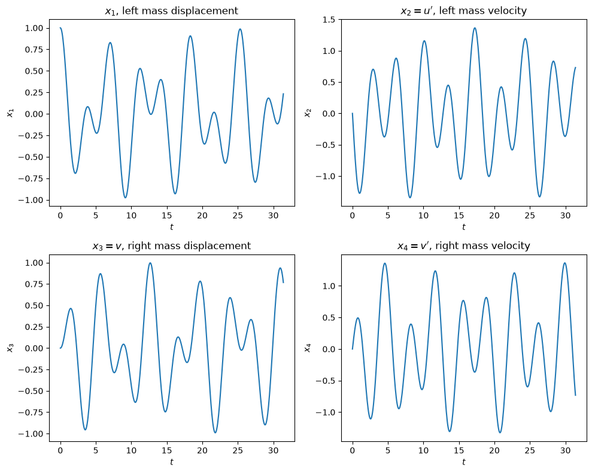

```python
import matplotlib.pyplot as plt
import numpy as np

# Define time grid and components
t = np.linspace(0, 10 * np.pi, 500)
x1 = 0.5*np.cos(t) + 0.5*np.cos(np.sqrt(3)*t)
x2 = -0.5*np.sin(t) - 0.5*np.sqrt(3)*np.sin(np.sqrt(3)*t)
x3 = 0.5*np.cos(t) - 0.5*np.cos(np.sqrt(3)*t)
x4 = -0.5*np.sin(t) + 0.5*np.sqrt(3)*np.sin(np.sqrt(3)*t)

# Create a figure and a 2x2 grid of subplots
fig, axes = plt.subplots(nrows=2, ncols=2, figsize=(10, 8))

# Plot on the first subplot (top-left)
axes[0, 0].plot(t, x1)
axes[0, 0].set_title('$x_1$, left mass displacement')
axes[0, 0].set_xlabel('$t$')
axes[0, 0].set_ylabel('$x_1$')

# Plot on the second subplot (top-right)
axes[0, 1].plot(t, x2)
axes[0, 1].set_title(r"$x_2=u'$, left mass velocity")
axes[0, 1].set_xlabel('$t$')
axes[0, 1].set_ylabel('$x_2$')

# Plot on the third subplot (bottom-left)
axes[1, 0].plot(t, x3)
axes[1, 0].set_title('$x_3=v$, right mass displacement')
axes[1, 0].set_xlabel('$t$')
axes[1, 0].set_ylabel('$x_3$')

# Plot on the fourth subplot (bottom-right)
axes[1, 1].plot(t, x4)
axes[1, 1].set_title(r"$x_4=v'$, right mass velocity")
axes[1, 1].set_xlabel('$t$')
axes[1, 1].set_ylabel('$x_4$')

# Adjust layout to prevent overlap
plt.tight_layout()

# Display the plot
plt.show()
```

# 2.37

# (i)

We set up

$$ \mathbf{x}' = \mathbf{A} \mathbf{x},$$

where $\mathbf{x} = [u, u', v, v']^T$ and

$$ \mathbf{A} = \left[ \begin{matrix} 0 & 1 & 0 & 0 \\ -2 & -2 & 1 & 0 \\ 0 & 0 & 0 & 1 \\ 1 & 0 & -2 & -2 \end{matrix} \right].$$

We can use SymPy to evaluate the matrix exponential, as well as form the general solution.

```python
#@title 2.37
from sympy import Symbol, Matrix, latex, simplify, exp, expand, transpose, symbols, expand_complex
from IPython.display import display, Math

t = Symbol('t', real=True)
#Define symbolic variables for the arbitrary column vector for the solution:
(c_1, c_2, c_3, c_4) = symbols('c_1 c_2 c_3 c_4')

#Here is where you enter the matrix as a list of the rows.
A = Matrix([[0,1,0,0],[-2,-2,1,0],[0,0,0,1],[1,0,-2,-2]])

#expand_complex() will have it rewrite complex exponentials using Euler's formula,
#and simplify() will have it combine like terms:
expA = simplify(expand_complex(exp(A*t)))

#Set up the column vector of arbitrary constants:
cvect = transpose(Matrix([[c_1, c_2, c_3, c_4]]))

#Mutiply the matrix exponential by the arbitrary column vector:
soln = expA*cvect

display(Math(r'\mathbf{A}='+latex(A)))
print()
print()
display(Math(r'e^{\mathbf{A}t}='+latex(expA)))
print()
print()
display(Math(r'\mathbf{x}(t)=e^{\mathbf{A}t}\mathbf{c}='+latex(soln)))
```

$\displaystyle \mathbf{A}=\left[\begin{matrix}0 & 1 & 0 & 0\\-2 & -2 & 1 & 0\\0 & 0 & 0 & 1\\1 & 0 & -2 & -2\end{matrix}\right]$

$\displaystyle e^{\mathbf{A}t}=\left[\begin{matrix}\frac{\left(2 t + \sqrt{2} \sin{\left(\sqrt{2} t \right)} + 2 \cos{\left(\sqrt{2} t \right)} + 2\right) e^{- t}}{4} & \frac{\left(2 t + \sqrt{2} \sin{\left(\sqrt{2} t \right)}\right) e^{- t}}{4} & \frac{\left(2 t - \sqrt{2} \sin{\left(\sqrt{2} t \right)} - 2 \cos{\left(\sqrt{2} t \right)} + 2\right) e^{- t}}{4} & \frac{\left(2 t - \sqrt{2} \sin{\left(\sqrt{2} t \right)}\right) e^{- t}}{4}\\- \frac{\left(2 t + 3 \sqrt{2} \sin{\left(\sqrt{2} t \right)}\right) e^{- t}}{4} & \frac{\left(- 2 t - \sqrt{2} \sin{\left(\sqrt{2} t \right)} + 2 \cos{\left(\sqrt{2} t \right)} + 2\right) e^{- t}}{4} & \frac{\left(- 2 t + 3 \sqrt{2} \sin{\left(\sqrt{2} t \right)}\right) e^{- t}}{4} & \frac{\left(- 2 t + \sqrt{2} \sin{\left(\sqrt{2} t \right)} - 2 \cos{\left(\sqrt{2} t \right)} + 2\right) e^{- t}}{4}\\\frac{\left(2 t - \sqrt{2} \sin{\left(\sqrt{2} t \right)} - 2 \cos{\left(\sqrt{2} t \right)} + 2\right) e^{- t}}{4} & \frac{\left(2 t - \sqrt{2} \sin{\left(\sqrt{2} t \right)}\right) e^{- t}}{4} & \frac{\left(2 t + \sqrt{2} \sin{\left(\sqrt{2} t \right)} + 2 \cos{\left(\sqrt{2} t \right)} + 2\right) e^{- t}}{4} & \frac{\left(2 t + \sqrt{2} \sin{\left(\sqrt{2} t \right)}\right) e^{- t}}{4}\\\frac{\left(- 2 t + 3 \sqrt{2} \sin{\left(\sqrt{2} t \right)}\right) e^{- t}}{4} & \frac{\left(- 2 t + \sqrt{2} \sin{\left(\sqrt{2} t \right)} - 2 \cos{\left(\sqrt{2} t \right)} + 2\right) e^{- t}}{4} & - \frac{\left(2 t + 3 \sqrt{2} \sin{\left(\sqrt{2} t \right)}\right) e^{- t}}{4} & \frac{\left(- 2 t - \sqrt{2} \sin{\left(\sqrt{2} t \right)} + 2 \cos{\left(\sqrt{2} t \right)} + 2\right) e^{- t}}{4}\end{matrix}\right]$

$\displaystyle \mathbf{x}(t)=e^{\mathbf{A}t}\mathbf{c}=\left[\begin{matrix}\frac{c_{1} \left(2 t + \sqrt{2} \sin{\left(\sqrt{2} t \right)} + 2 \cos{\left(\sqrt{2} t \right)} + 2\right) e^{- t}}{4} + \frac{c_{2} \left(2 t + \sqrt{2} \sin{\left(\sqrt{2} t \right)}\right) e^{- t}}{4} + \frac{c_{3} \left(2 t - \sqrt{2} \sin{\left(\sqrt{2} t \right)} - 2 \cos{\left(\sqrt{2} t \right)} + 2\right) e^{- t}}{4} + \frac{c_{4} \left(2 t - \sqrt{2} \sin{\left(\sqrt{2} t \right)}\right) e^{- t}}{4}\\- \frac{c_{1} \left(2 t + 3 \sqrt{2} \sin{\left(\sqrt{2} t \right)}\right) e^{- t}}{4} + \frac{c_{2} \left(- 2 t - \sqrt{2} \sin{\left(\sqrt{2} t \right)} + 2 \cos{\left(\sqrt{2} t \right)} + 2\right) e^{- t}}{4} + \frac{c_{3} \left(- 2 t + 3 \sqrt{2} \sin{\left(\sqrt{2} t \right)}\right) e^{- t}}{4} + \frac{c_{4} \left(- 2 t + \sqrt{2} \sin{\left(\sqrt{2} t \right)} - 2 \cos{\left(\sqrt{2} t \right)} + 2\right) e^{- t}}{4}\\\frac{c_{1} \left(2 t - \sqrt{2} \sin{\left(\sqrt{2} t \right)} - 2 \cos{\left(\sqrt{2} t \right)} + 2\right) e^{- t}}{4} + \frac{c_{2} \left(2 t - \sqrt{2} \sin{\left(\sqrt{2} t \right)}\right) e^{- t}}{4} + \frac{c_{3} \left(2 t + \sqrt{2} \sin{\left(\sqrt{2} t \right)} + 2 \cos{\left(\sqrt{2} t \right)} + 2\right) e^{- t}}{4} + \frac{c_{4} \left(2 t + \sqrt{2} \sin{\left(\sqrt{2} t \right)}\right) e^{- t}}{4}\\\frac{c_{1} \left(- 2 t + 3 \sqrt{2} \sin{\left(\sqrt{2} t \right)}\right) e^{- t}}{4} + \frac{c_{2} \left(- 2 t + \sqrt{2} \sin{\left(\sqrt{2} t \right)} - 2 \cos{\left(\sqrt{2} t \right)} + 2\right) e^{- t}}{4} - \frac{c_{3} \left(2 t + 3 \sqrt{2} \sin{\left(\sqrt{2} t \right)}\right) e^{- t}}{4} + \frac{c_{4} \left(- 2 t - \sqrt{2} \sin{\left(\sqrt{2} t \right)} + 2 \cos{\left(\sqrt{2} t \right)} + 2\right) e^{- t}}{4}\end{matrix}\right]$

# (ii)

As can be seen above, each component of $\mathbf{x}(t)$ is a linear combination of $e^{-t}, te^{-t}, e^{-t}\sin(\sqrt{2} t),$ and $e^{-t} \cos(\sqrt{2} t).$

Clearly,

$$\lim_{t \to \infty} e^{-t} = 0,$$

and

$$\lim_{t \to \infty} te^{-t} = \lim_{t \to \infty} \frac{t}{e^t} = 0$$

by L'Hospital's rule. We also have $\displaystyle \lim_{t \to \infty} e^{-t} \cos(\sqrt{2} t) = 0$ by the Squeeze Thoerem, since

$$ - e^{-t} \leq e^{-t} \cos(\sqrt{2} t) \leq e^{-t} \quad \text{ for all } t,$$

and similarly $\displaystyle \lim_{t \to \infty} e^{-t} \sin(\sqrt{2}t) = 0.$

It follows that for any $c_1, c_2, c_3, c_4$ that

$$\lim_{t \to \infty} \mathbf{x}(t) = \mathbf{0},$$

and so the origin $\mathbf{x}^\ast = \mathbf{0}$ is a globally asymptotically stable equilibrium solution.

This means that the friction in the system causes both mass positions to approach their equilibrium positions, with velocities also tending to zero.

(It turns out the eigenvalues are $\lambda_1 = \lambda_2 = -1, \lambda_{3,4} = -1 \pm \sqrt{2} i.$ All the real parts are strictly negative, which guarantees global asymptotic stability for a linear system.)

[Here is a Desmos link](https://www.desmos.com/calculator/0nk76yd9ap) with an animation of this system using the solution found above.

# 27.12

Transforming the ODE and initial conditions leads to

$$ (sY(s) - 1) - Y(s) = 0 \implies Y(s) = \frac{1}{s-1}.$$

Then, consulting the table of transforms,

$$ y(t) = e^{t}.$$

This is consistent with what we'd expect from the characteristic polynomial method.

(The book is using $x$ for the independent variable --- I like using "time" $t$ since it emphasizes that Laplace transforms are well suited for initial value problems where the input starts at 0.)

# 27.13

Transforming the ODE and initial conditions leads to

$$ (sY(s) - 1) - Y(s) = \frac{1}{s-1} \implies Y(s) = \frac{1}{s-1} + \frac{1}{(s-1)^2}.$$

Then, consulting the table of transforms ($\mathcal{L}\{t^n \} = \frac{n!}{s^{n+1}}$ and $\mathcal{L}\{e^{at}f(t) \} = F(s-a)$), we have

$$ y(t) = e^t+ t e^{t}.$$

This is consistent with what we'd expect from the characteristic polynomial and undetermined coefficients --- $y_c = c_1 e^{t}$ matches the inhomogeneity and so we'd have $y_p = Ate^{t}$.

# 27.14

Very similar to the previous problem, transforming the ODE and initial conditions leads to

$$ (sY(s) - 1) + Y(s) = \frac{1}{s+1} \implies Y(s) = \frac{1}{s+1} + \frac{1}{(s+1)^2}.$$

Then, consulting the table of transforms ($\mathcal{L}\{t^n \} = \frac{n!}{s^{n+1}}$ and $\mathcal{L}\{e^{at}f(t) \} = F(s-a)$), we have

$$ y(t) = e^{-t} + t e^{-t}.$$

This is consistent with what we'd expect from the characteristic polynomial and undetermined coefficients --- $y_c = c_1 e^{-t}$ matches the inhomogeneity and so we'd have $y_p = Ate^{-t}.$

# 27.15

Transforming the ODE yields

$$(s^2Y(s)-s-1) + 4(sY(s) - 1) + 4Y(s) = 0.$$

Rearranging, we have

$$(s^2+4s+4)Y(s) = s+5 \implies Y(s) = \frac{s+5}{(s+2)^2}.$$

While you could set up a partial fraction decomposition $\dfrac{A}{s+2} + \dfrac{B}{(s+2)^2},$ it is probably simplier to just do

$$Y(s) = \frac{s+5}{(s+2)^2} = \frac{(s+2)+3}{(s+2)^2} = \frac{1}{s+2} + \frac{3}{(s+2)^2}$$

and then conclude

$$y(t) = e^{-2t} + 3te^{-2t}.$$

# 27.20

Transforming the ODE yields

$$s^3 Y(s) - 2s^2 Y(s) + sY(s) = \frac{2}{s-1} + \frac{2}{s^2} \implies s(s^2-2s+1)Y(s) = \frac{2}{s-1} + \frac{2}{s^2} = \frac{2s^2 + 2s-2}{s^2(s-1)},$$

and so

$$Y(s) = \frac{2s^2+2s-2}{s^3(s-1)^3}.$$

This proper rational function with denominator $s^3(s-1)^3$ should have a partial fraction decomposition of the form

$$\frac{2s^2+2s-2}{s^3(s-1)^3} = \frac{A}{s} + \frac{B}{s^2} + \frac{C}{s^3} + \frac{D}{s-1} + \frac{E}{(s-1)^2} + \frac{F}{(s-1)^3}$$

since we have two linear factors, each with multiplicity 3. We can use Sympy:

```python
from IPython.display import display, Math
from sympy import *

s = Symbol('s', real = True)

f = (2*s**2+2*s-2)/(s**3*(s-1)**3)

partialfrac = apart(f, s)

display(Math(latex(f)+' = '+latex(partialfrac)))
```

$\displaystyle \frac{2 s^{2} + 2 s - 2}{s^{3} \left(s - 1\right)^{3}} = - \frac{4}{s - 1} + \frac{2}{\left(s - 1\right)^{3}} + \frac{4}{s} + \frac{4}{s^{2}} + \frac{2}{s^{3}}$

Then, since

$$Y(s) = -\frac{4}{s-1} + \frac{2}{(s-1)^3} + \frac 4 s + \frac{4}{s^2} + \frac{2}{s^3},$$

we have (using the table)

$$y(t) = -4e^{t} + t^2e^t + 4 + 4t + t^2.$$